# Untidy Movie Data

Matthew Tillmawitz

2024-10-06

## Reading the Data

The file is actually semicolon separated, but it is simple to read in using read_delim. An initial look shows that overall the data is well structured, but would benefit from collapsing the genre data.

```r
raw_data <- read_delim('https://raw.githubusercontent.com/Tillmawitz/data_607/refs/heads/main/project_2/movies.csv', delim = ";")
raw_data
```

```
## # A tibble: 3,883 × 21
##    Name     ReleaseDate Action Adventure Children Comedy Crime Documentary Drama
##    <chr>          <dbl>  <dbl>     <dbl>    <dbl>  <dbl> <dbl>       <dbl> <dbl>
##  1 Toy Sto…        1995      0         0        1      1     0           0     0
##  2 Jumanji…        1995      0         1        1      0     0           0     0
##  3 Grumpie…        1995      0         0        0      1     0           0     0
##  4 Waiting…        1995      0         0        0      1     0           0     1
##  5 Father …        1995      0         0        0      1     0           0     0
##  6 Heat (1…        1995      1         0        0      0     1           0     0
##  7 Sabrina…        1995      0         0        0      1     0           0     0
##  8 Tom and…        1995      0         1        1      0     0           0     0
##  9 Sudden …        1995      1         0        0      0     0           0     0
## 10 GoldenE…        1995      1         1        0      0     0           0     0
## # ℹ 3,873 more rows
## # ℹ 12 more variables: Fantasy <dbl>, Noir <dbl>, Horror <dbl>, Musical <dbl>,
## #   Mystery <dbl>, Romance <dbl>, SciFi <dbl>, Thriller <dbl>, War <dbl>,
## #   Western <dbl>, AvgRating <dbl>, Watches <dbl>
```

## Collapsing the Data

Tidying the data is fairly simple and can be achieved by pivoting the genre column names into a single column called “genre” and mapping the values to a separate column. By filtering the rows containing the genres the movie is not in we have a nice data set tracking all the relavant information.

```r
tidied <- raw_data |>
  pivot_longer(cols = Action:Western, names_to = "genre", values_to = "in_genre") |>
  filter(in_genre == 1) |>
  select(!in_genre)

tidied
```

```
## # A tibble: 6,303 × 5
##    Name                               ReleaseDate AvgRating Watches genre
##    <chr>                                    <dbl>     <dbl>   <dbl> <chr>
##  1 Toy Story (1995)                          1995      4.15    2077 Children
##  2 Toy Story (1995)                          1995      4.15    2077 Comedy
##  3 Jumanji (1995)                            1995      3.2      701 Adventure
##  4 Jumanji (1995)                            1995      3.2      701 Children
##  5 Jumanji (1995)                            1995      3.2      701 Fantasy
##  6 Grumpier Old Men (1995)                   1995      3.02     478 Comedy
##  7 Grumpier Old Men (1995)                   1995      3.02     478 Romance
##  8 Waiting to Exhale (1995)                  1995      2.73     170 Comedy
##  9 Waiting to Exhale (1995)                  1995      2.73     170 Drama
## 10 Father of the Bride Part II (1995)        1995      3.01     296 Comedy
## # ℹ 6,293 more rows
```

It should be noted that even this format has a fair amount of repeated information. The trade off is worth it to make aggregations and analysis easier, but outside of the analytic environment the data would be better stored in two different tables. By separating the repeated columns (all except genre) the information can be more easily updated without the risk of diverging edits. The table used for analysis can be easily reconstructed using a join on the Name column.

```r
movie_information <- tidied |>
  select(!genre) |>
  distinct()

genre_information <- tidied |>
  select(Name, genre)
```

## Data Analysis

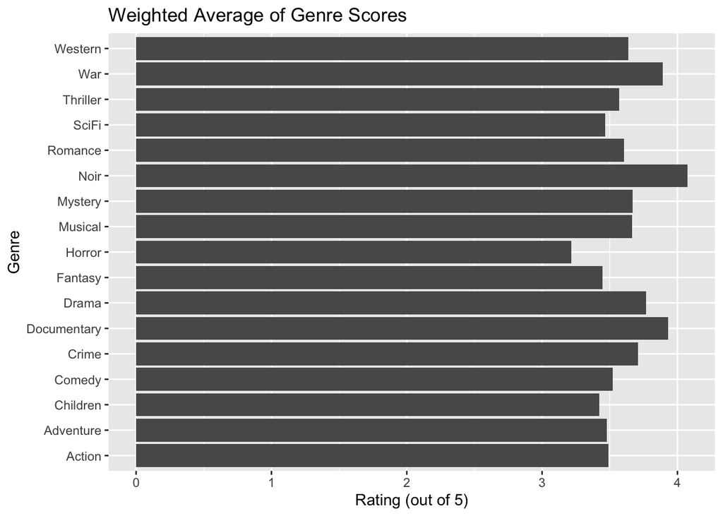

```r
tidied |>
  group_by(genre) |>
  summarise(weighted_rating = weighted.mean(AvgRating, Watches)) |>
  ggplot(aes(weighted_rating, genre)) +
  geom_col() +
  labs(title = "Weighted Average of Genre Scores", x = "Rating (out of 5)", y = "Genre")
```

Moving on, we can take a look at how the release rates of the genres vary over time to begin to explore genre popularity. The data has been windowed to years after 1980 to allow modern trends to be more apparent. The number of releases increases dramatically with time, so trends in the early years of the dataset are masked by the scale of later trends. Looking at the plot it is clear the genres with the most releases over this period are Drama and Comedy, a bit of an amusing juxtaposition.

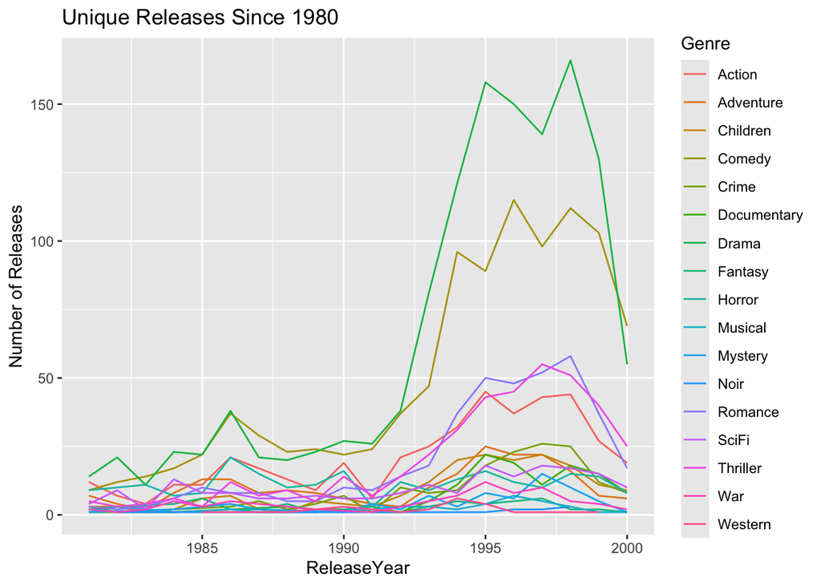

```r
tidied |>
  filter(ReleaseDate > 1980) |>
  count(genre, ReleaseDate) |>
  ggplot(aes(x = ReleaseDate, y = n, color = genre)) +
  geom_line() +
  labs(title = "Unique Releases Since 1980", x = "ReleaseYear", y = "Number of Releases", color = "Genre")
```

If we instead use viewership as a metric of popularity we see the same two genres on top, but the gap between them and the other genres is decreasing. This indicates the viewership of the top genres may be inflated by having more overall releases.

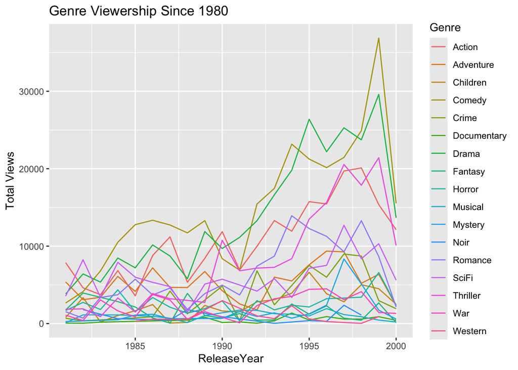

```r
tidied |>
  filter(ReleaseDate > 1980) |>
  group_by(genre, ReleaseDate) |>
  summarise(total_views = sum(Watches)) |>
  ggplot(aes(x = ReleaseDate, y = total_views, color = genre)) +
  geom_line() +
  labs(title = "Genre Viewership Since 1980", x = "ReleaseYear", y = "Total Views", color = "Genre")
```

By measuring viewership per release we can get a scaled metric that accounts for viewership inflation due to the number of releases. Doing so shows us that by and large the genres are equally popular. There are some spikes on a given year but overall the genres vary within a very similar range and trade places frequently.

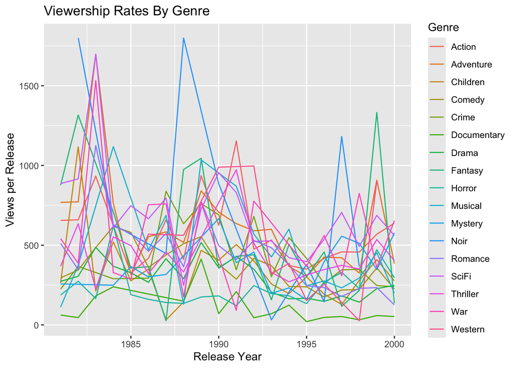

```r
viewership_counts <- tidied |>
  filter(ReleaseDate > 1980) |>
  group_by(genre, ReleaseDate) |>
  count() |>
  rename(releases = n)

tidied |>
  filter(ReleaseDate > 1980) |>
  group_by(genre, ReleaseDate) |>
  summarise(total_views = sum(Watches)) |>
  full_join(viewership_counts) |>
  mutate(views_per_release = total_views/releases) |>
  ggplot(aes(x = ReleaseDate, y = views_per_release, color = genre)) +
  geom_line() +
  labs(x = "Release Year", y = "Views per Release", title = "Viewership Rates By Genre", color = "Genre")
```

As a fun additional look we can see that on average a movie fits into 1.6 genres and the most genres a movie had was 5.

```r
tidied |>
  count(Name) |>
  summarise(average = mean(n), max = max(n))
```

```
## # A tibble: 1 × 2
##   average   max
##     <dbl> <int>
## 1    1.62     5
```